# Human Activity Recognition Project

by weisdata

09-26-2015

### *EXECUTIVE SUMMARY*

Qualtified self is a fashionable world wide movement now. Enthusiasts love to take measurements about themselves regularly to improve health, to find patterns in behaviors, or just to have fun. [Groupware@LES](http://groupware.les.inf.puc-rio.br/har) kindly opens their collected data for this Human Activity Recognition Project. In this project, I will conduct a machine learning algorithem to predict the human activity, ie. the manner in which huamn did the exercise.

To address this problem, I propose the following:

1. *Data Cleaning*. This will allow me to spot problems, finding outliers, invalid and missing values.
2. *Modeling*. This will allow me to build models to find information and patterns in the data and do predictions.

### Data Cleaning

The data ([Train Set](https://d396qusza40orc.cloudfront.net/predmachlearn/pml-training.csv) and [Test Set](https://d396qusza40orc.cloudfront.net/predmachlearn/pml-testing.csv) ) were collected from accelerometers on the belt, forearm, arm, and dumbell of 6 participants.

Moreover, factor variable `cvtd_timestamp` has different levels in training and test sets, respectively. Thus, I split it into the date(`cvtd_timestamp_date`) and time(`cvtd_timestamp_time`) and delete the original one in both training and test sets. Also, the first column represents the serial number, revealing no information about the date.

### Modeling

In this part, I first slice the original training set into `trainS` and `testS` sets for model building and accuracy validation. Then it is time to build models.

```r
set.seed(1010)
inTrain <- createDataPartition(y = training$classe, p = 0.6, list = FALSE)
trainS <- training[inTrain, ]
testS <- training[-inTrain, ]
dim(trainS)
```

[output not shown]

I conduct three classification algorithems to learning, decision tree, bagging and random forest. The models statistics comparision is shown in the following table. From the comparison, we can find the ideal model is the random forest, with a rather high accuracy rate of 99.92%.

```r
# Decision tree
library(caret)
set.seed(10)
modfit_rpart <- train(classe ~ ., method = "rpart", data = trainS)
# Bagging
library(party)
set.seed(101010)
modfit_bag <- bag(trainS[, -57], trainS$classe, B = 10, bagControl = bagControl(fit = ctreeBag$fit,
    predict = ctreeBag$pred, aggregate = ctreeBag$aggregate))
# Random Forest
library(randomForest)
set.seed(10101010)
modrf <- randomForest(classe ~ ., data = trainS, importance = T)
```

Models Overall Statistics Comparison (continued below)

| Model | Accuracy | 95% CI | No Info Rate |
| --- | --- | --- | --- |
| Decision Tree | 0.5172 | 0.5061, 0.5283 | 0.2845 |
| Bagging | 0.9785 | 0.975, 0.9816 | 0.2845 |
| Random Forest | 0.9992 | 0.9983, 0.9997 | 0.2845 |

| P-Value[Acc > NIR] | Kappa | Mcnemar’s P-Value |
| --- | --- | --- |
| 0 | 0.3706 | 0 |
| 0 | 0.9728 | 0.4744 |
| 0 | 0.999 | NaN |

Specifically, in these models, there is no need for cross-validation or a separate test set to get an unbiased estimate of the test set error. It is estimated internally. Take random forest for example, during the run, as follows:

- Each tree is constructed using a different bootstrap sample from the original data. About one-third of the cases are left out of the bootstrap sample and not used in the construction of the kth tree.
- Put each case left out in the construction of the kth tree down the kth tree to get a classification. In this way, a test set classification is obtained for each case in about one-third of the trees. At the end of the run, take j to be the class that got most of the votes every time case n was oob. The proportion of times that j is not equal to the true class of n averaged over all cases is the oob error estimate. This has proven to be unbiased in many tests.

Based on the random forest model, furthermore, I dig into the features to refine the model. Figure *Variable Importance Plot* reveals the top important variables, which are clues for further features reduction. Therefore, I pick up the top 25 most important variable to conduct a new random forest model.

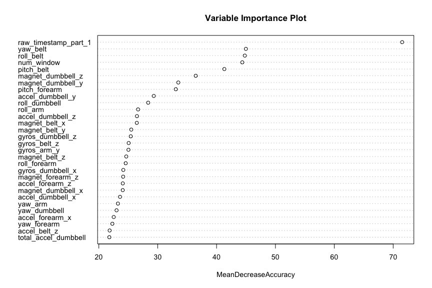

Variable Importance Plot

```
##
## Call:
##  randomForest(formula = classe ~ ., data = trainS[, c(varImp25,      "classe")], importance = T)
##                Type of random forest: classification
##                      Number of trees: 500
## No. of variables tried at each split: 5
##
##         OOB estimate of  error rate: 0.11%
## Confusion matrix:
##      A    B    C    D    E class.error
## A 3348    0    0    0    0   0.0000000
## B    4 2275    0    0    0   0.0017552
## C    0    3 2050    1    0   0.0019474
## D    0    0    3 1926    1   0.0020725
## E    0    0    0    1 2164   0.0004619
```

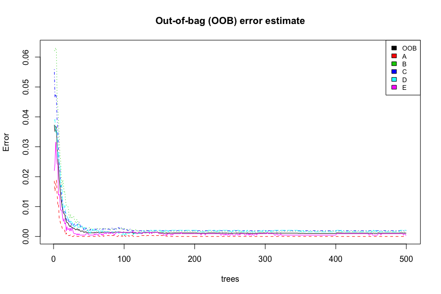

Out-of-bag (OOB) Error Estimate

### Prediction

Sum up, the final model is the random forest with the selected 25 predictors. The final part of this project is to predict the given 20 observations in the test set.

```
##  1  2  3  4  5  6  7  8  9 10 11 12 13 14 15 16 17 18 19 20
##  B  A  B  A  A  E  D  B  A  A  B  C  B  A  E  E  A  B  B  B
## Levels: A B C D E
```